# NEPA Clean Energy Analysis

Phase 1 Findings

Clean Air Task Force

March 05, 2026

## Agenda

**Phase 1 Deliverables**

1. Project Background & Data
2. **D1** — Clean Energy Project Landscape
3. **D2** — Programmatic & Tiered Reviews
4. **D3** — NEPA Process Types, Timelines & Generation Capacity
5. **D4** — Multi-State & Multi-Agency Projects
6. **D5** — Document Length & Fiscal Responsibility Act Impact
7. **D6** — Technology Deep Dives: Transmission, Geothermal, Pipelines
8. Discussion & Next Steps

**Format**

~30 minutes of content ~15 minutes for open discussion

**Full reports:** nepa.catf.us

Appendix slides follow the main deck with additional detail, methodology, and the NEPA policy timeline.

# Project Background & Data

## The NEPATEC 2.0 Dataset

**Source:** [NEPATEC 2.0](https://huggingface.co/datasets/PNNL/NEPATEC2.0) — PNNL PermitAI The most comprehensive public NEPA database ever assembled.

- **60,000+** total federal projects
- **120,000+** NEPA documents
- 60+ federal agencies, 2000–2024
- Machine-readable full text (JSON)

**Why this matters:** Before NEPATEC 2.0, researchers had to assemble bespoke subsets of NEPA data — limiting systematic analysis of review patterns at scale.

**Clean Energy Universe:**

- ~25,000 projects initially tagged as clean energy
- **20,725** retained after exclusion criteria

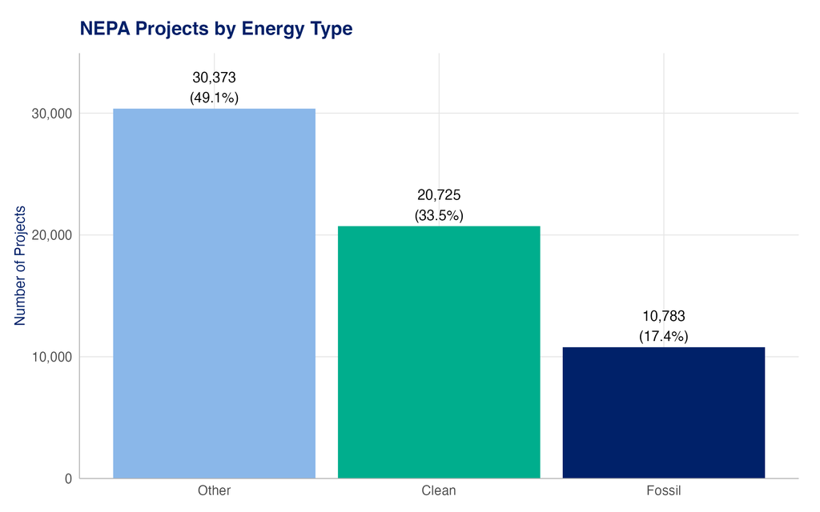

## Defining Clean Energy — Part 1: Tag System

**Clean Energy Tags** *(at least 1 required AND no Fossil Fuel tags)*

| Tag |
| --- |
| Carbon Capture and Sequestration |
| Conventional Energy Production — Nuclear |
| Conventional Energy Production — Other |
| Electricity Transmission |
| Nuclear Technology |
| Renewable Energy Production — Biomass |
| Renewable Energy Production — Energy Storage |
| Renewable Energy Production — Geothermal |
| Renewable Energy Production — Hydrokinetic |
| Renewable Energy Production — Hydropower |
| Renewable Energy Production — Solar |
| Renewable Energy Production — Wind (Offshore) |
| Renewable Energy Production — Wind (Onshore) |
| Utilities (electricity, gas, telecommunications) |

**Fossil Energy Tags** *(any 1 excludes)*

| Tag |
| --- |
| Conventional Energy — Coal |
| Conventional Energy — Land-based Oil & Gas |
| Conventional Energy — Offshore Oil and Gas |
| Conventional Energy — Rural Energy |
| Pipelines |

About **10%** of projects have only clean energy tags; the remaining 90% have at least one clean energy tag alongside other tags.

## Defining Clean Energy — Part 2: Exclusion Rules

Three additional exclusions were applied after reviewing co-occurring tag combinations:

**Exclusion 1 — Utilities + non-energy only**

- **1,623 projects** tagged *only* as Utilities AND with non-energy tags (broadband, waste management, land development) were excluded — these reflect utility-adjacent infrastructure, not energy generation.

**Exclusion 2 — Military & Defense + Nuclear**

- **481 projects** tagged as Nuclear AND Military/Defense were excluded. Most are DOE-led but involve weapons-related activities, not energy production.

**Exclusion 3 — Nuclear + Waste Management**

- ~4,000 nuclear waste projects reviewed; those sponsored by DOE’s NNSA, Office of Environmental Management, and Office of Legacy Management were excluded. Only **34 projects** from this category were retained as relevant to clean energy analysis.

**Result:** **20,725** clean energy projects across all six Phase 1 deliverables.

## Phase 1 Deliverables at a Glance

| Deliverable | Focus |
| --- | --- |
| **D1** — Clean Energy Project Landscape | How are 20,725 clean energy projects distributed across technologies, lead agencies, and geographies? |
| **D2** — Programmatic & Tiered Reviews | How common are programmatic and tiered reviews among EA/EIS projects, and do they actually deliver faster outcomes? |
| **D3** — NEPA Process, Timelines & Capacity | How do CE, EA, and EIS differ in duration and project scale? How has activity changed over time? |
| **D4** — Multi-State & Multi-Agency | Which projects cross state boundaries or involve multiple federal agencies, and how are they distributed? |
| **D5** — Document Length & FRA Impact | Did the Fiscal Responsibility Act of 2023 page limits change how long NEPA documents are? |
| **D6** — Technology Deep Dives | Deep analysis of electricity transmission, geothermal energy, and carbon/hydrogen pipelines. |

# Deliverable 1

## Clean Energy Project Landscape

**20,725 clean energy projects** identified across the federal NEPA database.

This section covers how they are distributed by **technology type**, **lead agency**, and **geography** — establishing the foundational picture of where federal clean energy permitting happens and who is responsible for it.

## Technology Distribution

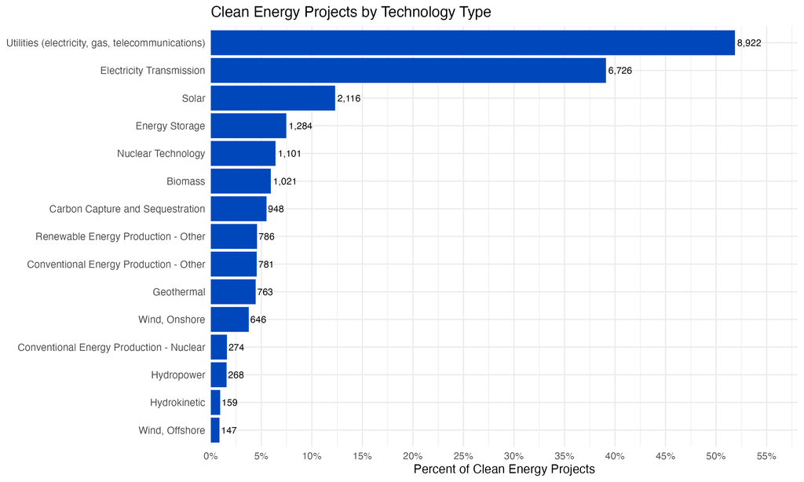

Projects by technology type

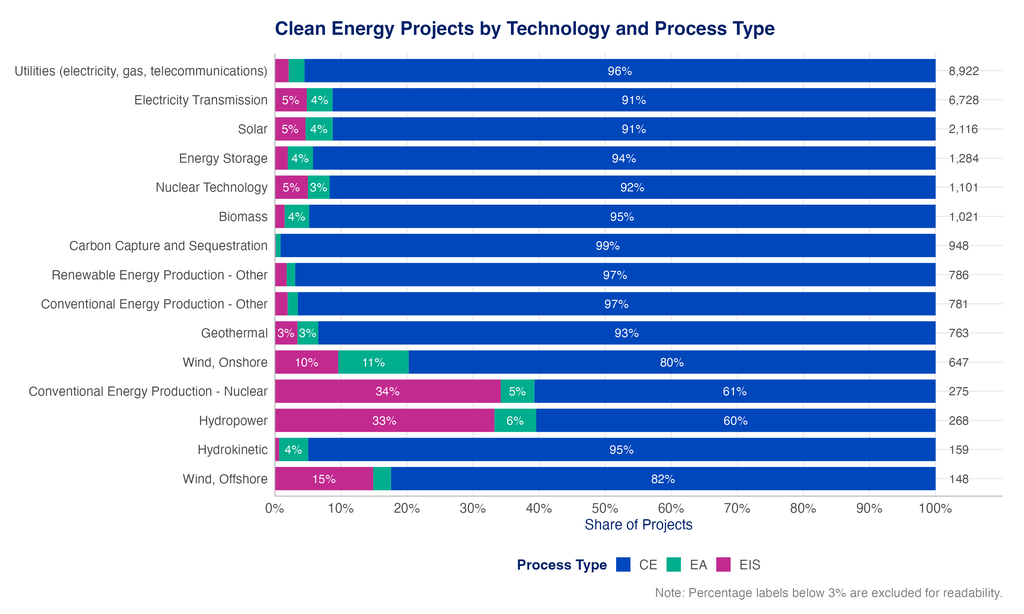

Technology by NEPA process type

## Lead Agencies

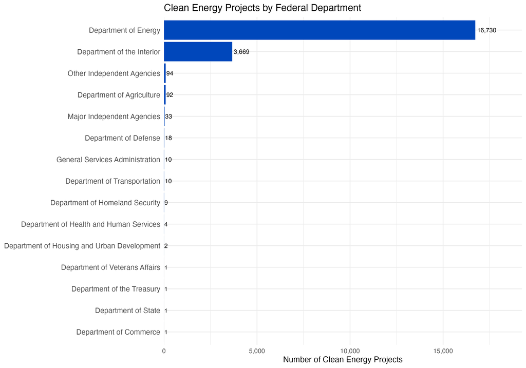

**DOE processes 81% of clean energy projects** — and 96% of those through Categorical Exclusions.

Interior handles 17% of projects with a more varied process mix.

**Why DOE dominates:**

- Loan programs & grid modernization grants
- Power Marketing Administrations
- National Laboratory site operations

Most other agencies have substantially higher EA/EIS shares when they are the lead agency.

## Geographic Distribution

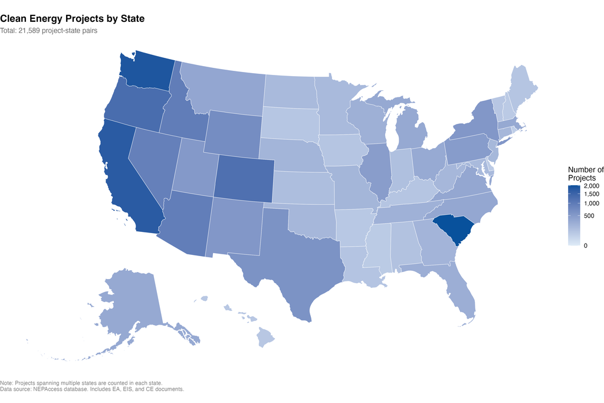

**Top 5 States**

1. South Carolina *(Savannah River Site)*
2. Washington
3. California
4. Idaho
5. Colorado

**County-Level Coverage**

[output not shown]

EA/EIS projects missing county data are estimated ~99% recoverable via reverse geocoding.

## D1 Key Takeaways

**Scale:** 20,725 clean energy projects — larger than previously documented

**DOE dominance:** 81% of projects, 96% via CE — the clean energy permitting story is largely a DOE Categorical Exclusion story

**Geography:** South Carolina leads due to one federal nuclear facility — context is essential when reading geographic distributions

**Coverage:** County-level data gaps are concentrated in CEs and are largely recoverable; EA/EIS geographic coverage is solid

# Deliverable 2

## Programmatic & Tiered Reviews

Among the **EA and EIS** projects in our dataset, some use **programmatic** reviews (covering a broad class of actions) or **tiered** reviews (site-specific, building on a prior programmatic review).

This section examines how common these approaches are, which agencies use them, and whether they actually speed up the environmental review process.

## Prevalence: Most EA/EIS Reviews Are Standard

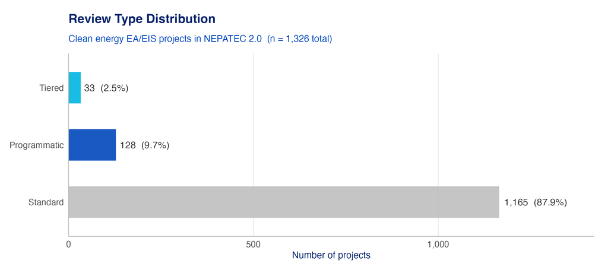

Review type distribution across EA/EIS

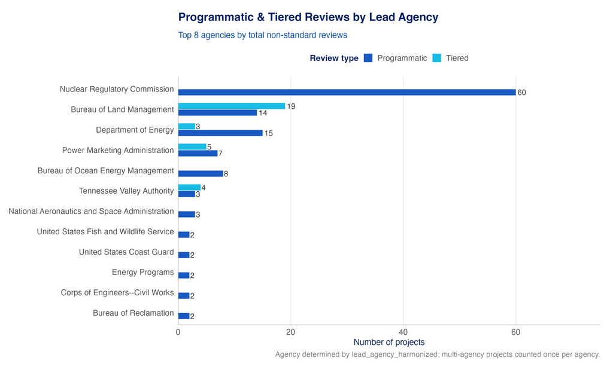

- **Standard:** Stand-alone EA/EIS covering a single project
- **Programmatic:** Broad “umbrella” review (PEIS/PEA) covering a class of actions or region
- **Tiered:** Site-specific review that builds on a prior programmatic review

## Are Tiered Reviews Actually Faster?

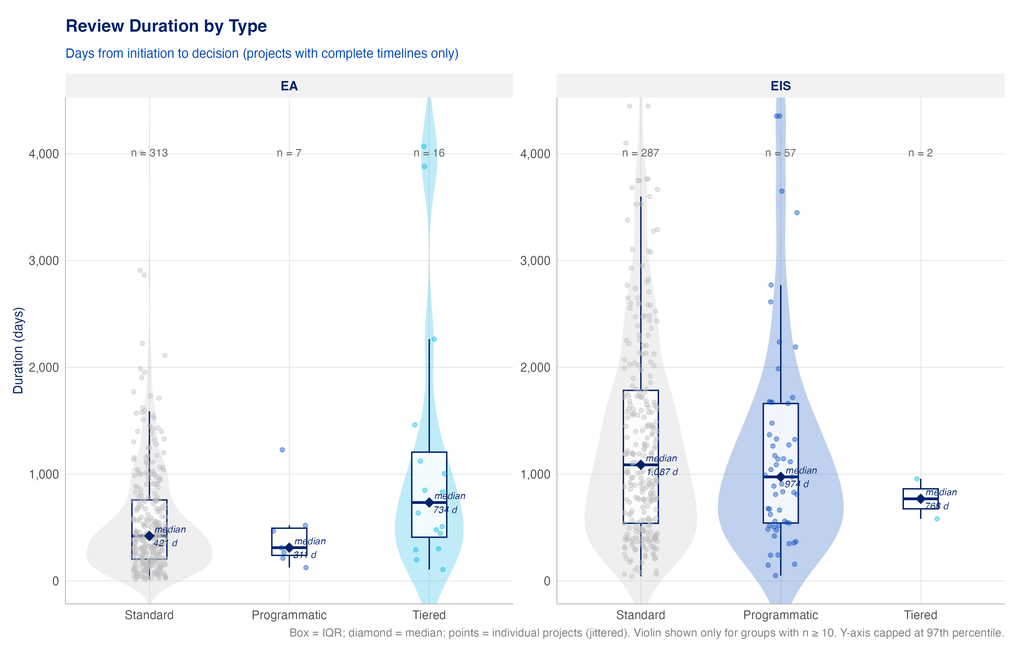

**Median review durations:**

[output not shown]

**Tiered EAs are longer than standard EAs.** Programmatic EISs are modestly faster, but the distributions substantially overlap.

**Warning**

Small sample for tiered EIS limits conclusions there.

## D2 Key Takeaways

**Speed:** Tiering does **not** reliably speed up review — tiered EAs take longer than standard EAs on average

**Policy implication:** Expanding tiering requirements alone will not accelerate permitting without addressing root causes of EA/EIS duration

# Deliverable 3

## NEPA Process Types, Timelines & Generation Capacity

The three NEPA process types — **Categorical Exclusion (CE)**, **Environmental Assessment (EA)**, and **Environmental Impact Statement (EIS)** — differ dramatically in scope, duration, and the scale of projects they cover.

This section compares review durations, tracks how NEPA activity has changed over time (including the ARRA and IRA/BIL investment waves), and shows how generation capacity scales with review intensity.

## How Long Does NEPA Review Take?

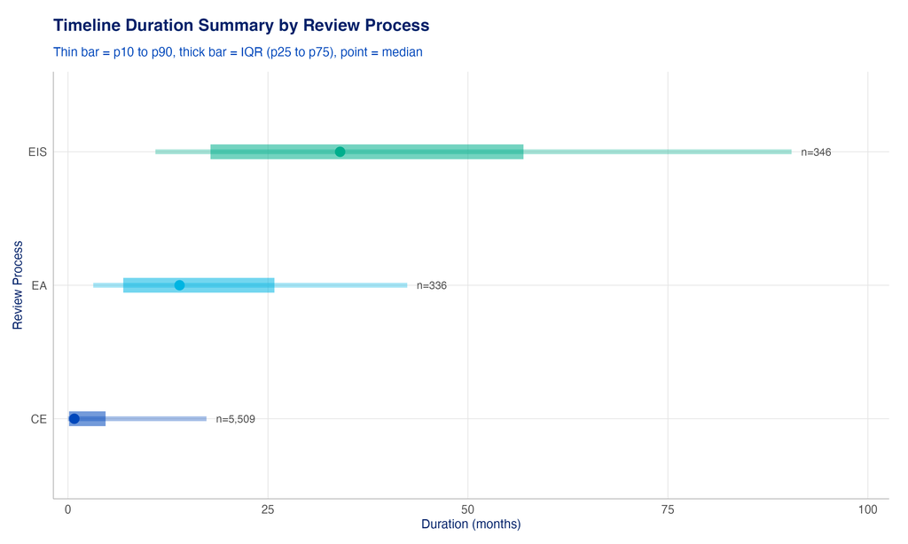

**Median durations:**

- CE: **~1 month**
- EA: **~14 months**
- EIS: **~34 months** (3 years)

**EIS 90th percentile: > 7.5 years**

**Timeline completeness** (projects with both initiation + decision dates):

| Process | Complete |
| --- | --- |
| CE | 30% |
| EA | 62% |
| EIS | 48% |

Dates extracted via BERT NLP pipeline from document text

## NEPA Activity Over Time

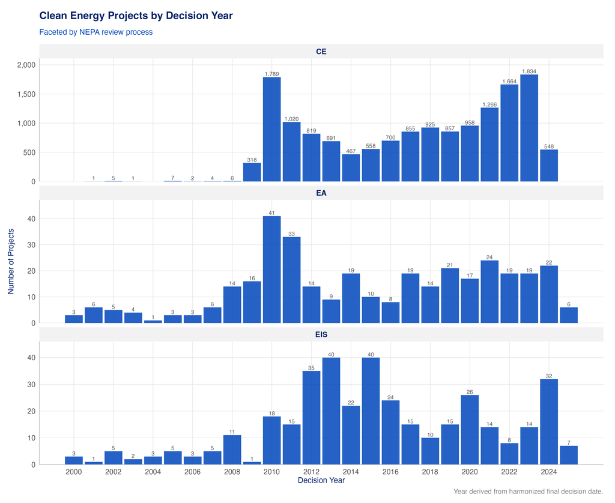

**CE peaked in 2010** (ARRA stimulus) and again in **2023.** The IRA/BIL investment surge from 2022 onward has not yet fully appeared — projects initiated recently will complete in 2025–2027.

## Generation Capacity by Review Process

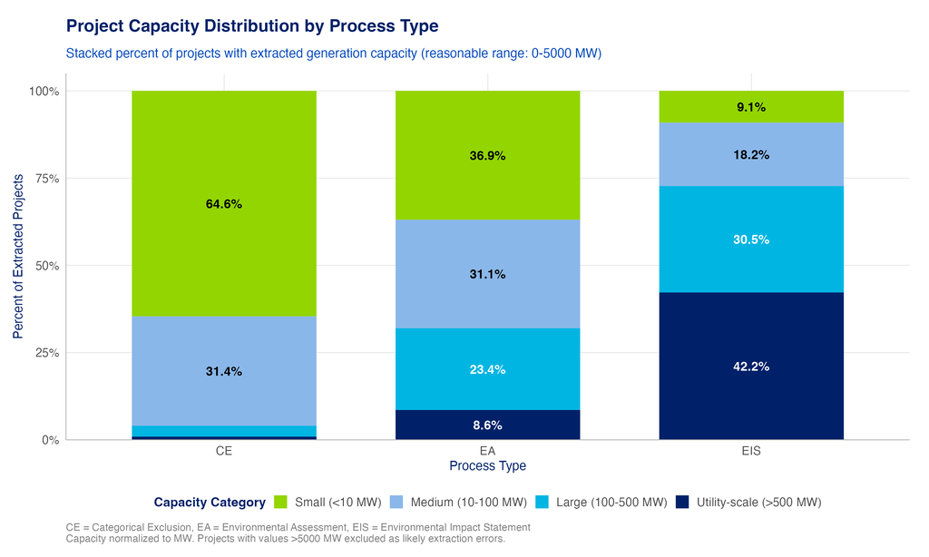

Capacity distribution (stacked)

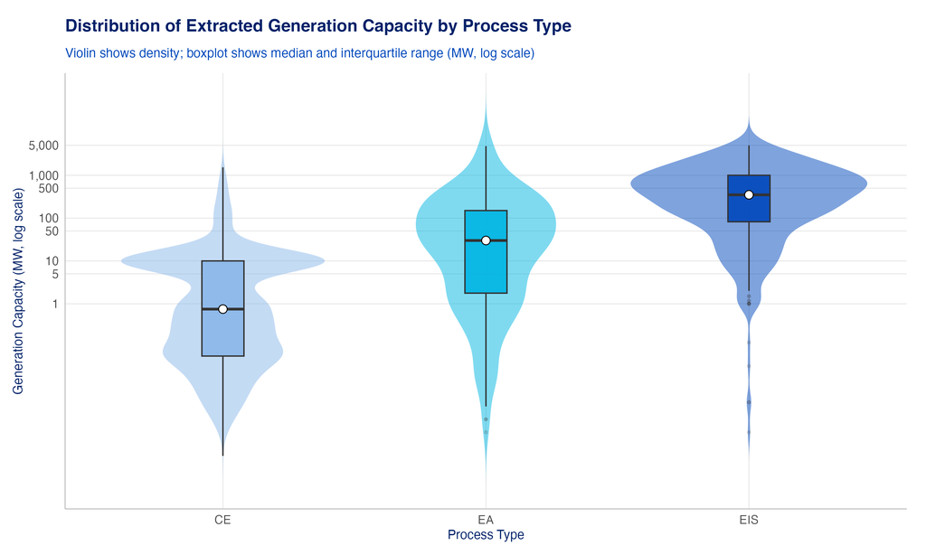

Violin + boxplot by process

## D3 Key Takeaways

**Duration gradient:** CE ~1 month → EA ~14 months → EIS ~3 years; the difference is real and large

**Long tail:** 10% of EIS reviews take more than 7.5 years — these outliers drive the NEPA delay narrative but are not typical

**Policy signals in the data:** ARRA (2010) and IRA/BIL (2022–) are visible; the full IRA cohort of EAs/EISs is still working through the pipeline

**Proportionality:** Review intensity broadly matches project scale — the largest projects appropriately receive EIS-level review

# Deliverable 4

## Multi-State & Multi-Agency Projects

Long-distance transmission lines, pipelines, and large renewable projects often cross **multiple state boundaries** or require sign-off from **multiple federal agencies** — adding coordination complexity to an already demanding review process.

This section maps where cross-boundary projects concentrate, which agencies collaborate most, and what types of review they typically require.

## Multi-State Projects

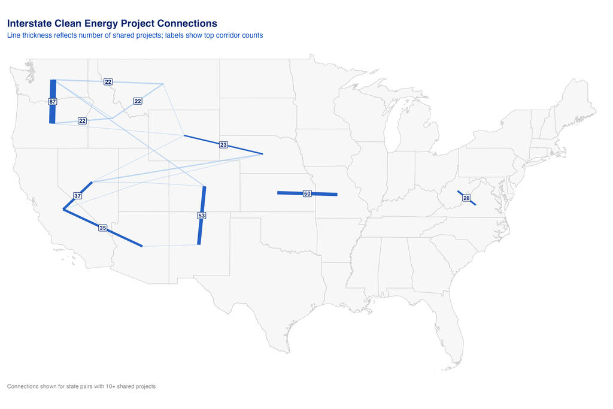

State-to-state project connections

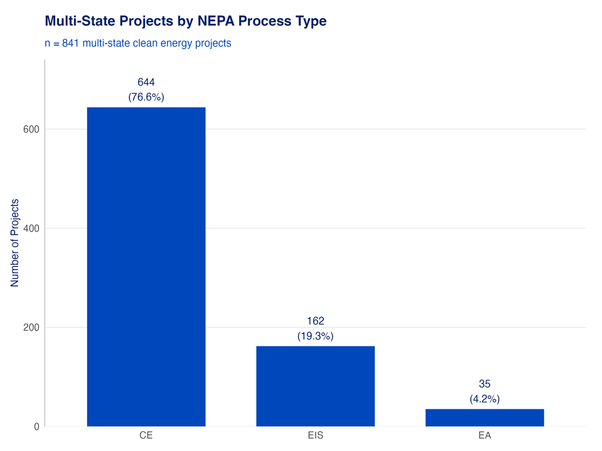

Multi-state projects span state boundaries — long-haul transmission lines, right-of-way corridors, utility-scale renewables.

## Multi-Agency Collaboration

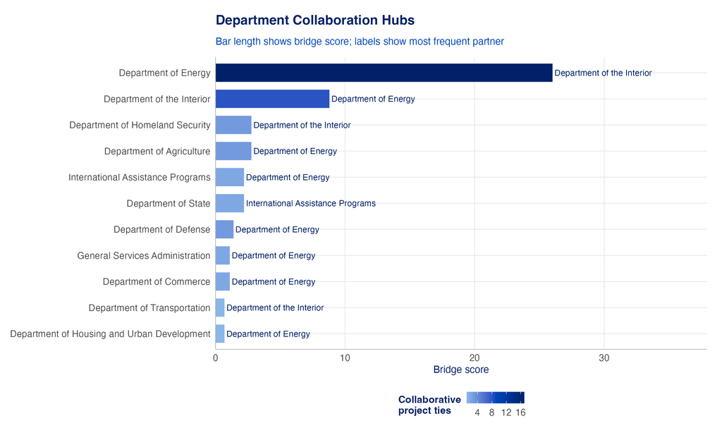

Department collaboration hub scores

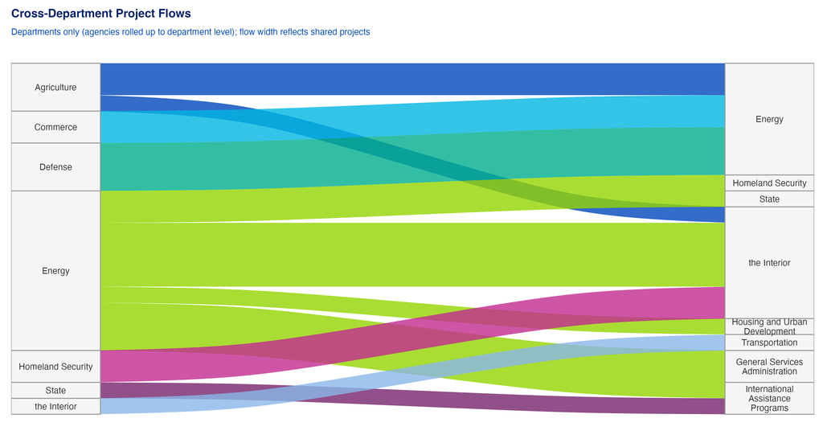

Cross-department project flows

Multi-agency projects are **89% EIS** | **DOE bridge score: 26** (clear hub, 9 partner agencies) | **DOI bridge score: 9** (secondary hub)

## D4 Key Takeaways

**Geography:** Western states drive cross-state NEPA activity — the clean energy transmission build-out is fundamentally a western story

**DOE as hub:** DOE is the connective tissue of multi-agency review, partnering with 9 different departments

**Policy implication:** Improving coordination among DOE, DOI, and USDA would have outsized impact on the most complex clean energy reviews

# Deliverable 5

## Document Length & Fiscal Responsibility Act Impact

The **Fiscal Responsibility Act of 2023 (FRA)** established statutory page limits for NEPA documents — 75 pages for EAs and 150 pages (300 for complex projects) for EISs.

This section examines whether NEPA document lengths actually changed after the FRA and how well current documents comply with the new limits, using **regulatory page counts** (body words ÷ 500) to match the statutory definition.

## The FRA 2023 Page Limits

The **Fiscal Responsibility Act (June 2023)** established statutory page limits for NEPA documents:

| Document | Standard Limit | Complex Limit |
| --- | --- | --- |
| Environmental Assessment (EA) | **75 pages** | — |
| Environmental Impact Statement (EIS) | **150 pages** | **300 pages** |

**What counts as a “page”?** *(40 C.F.R. § 1508.1(bb))*

> Body word count ÷ 500 — **excludes** maps, figures, tables, appendices, citations

## Document Length Trends Over Time

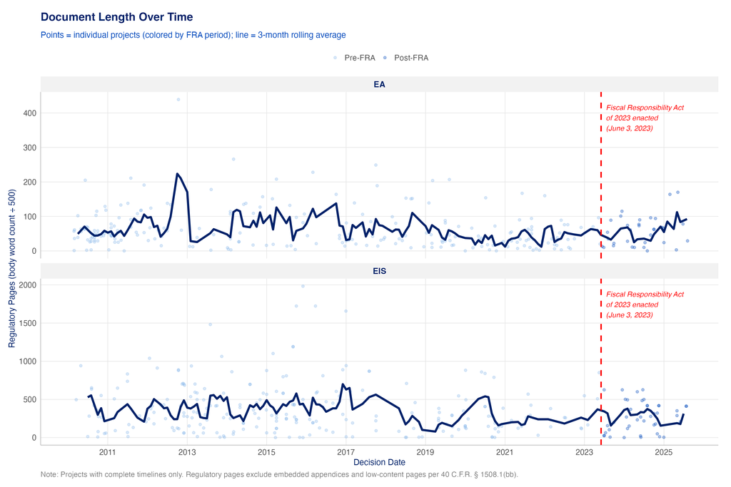

**Warning**

Small post-FRA sample: only 33 EAs and 42 EISs completed after June 2023. Conclusions will strengthen as more post-FRA documents accumulate.

## Pre/Post FRA: Lengths & Compliance

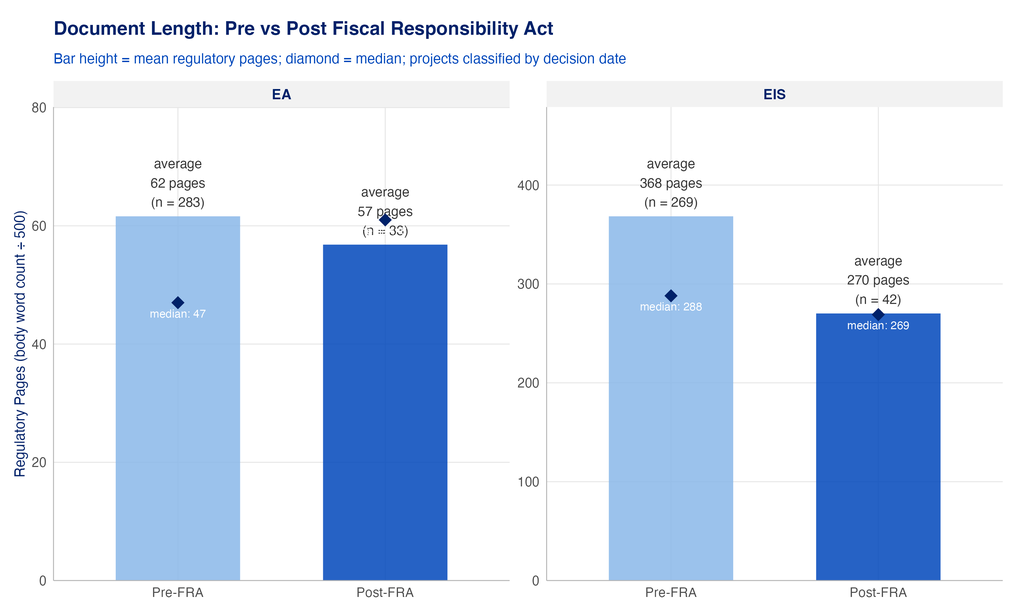

Pre vs. Post-FRA page count comparison

**Regulatory page medians:**

[output not shown]

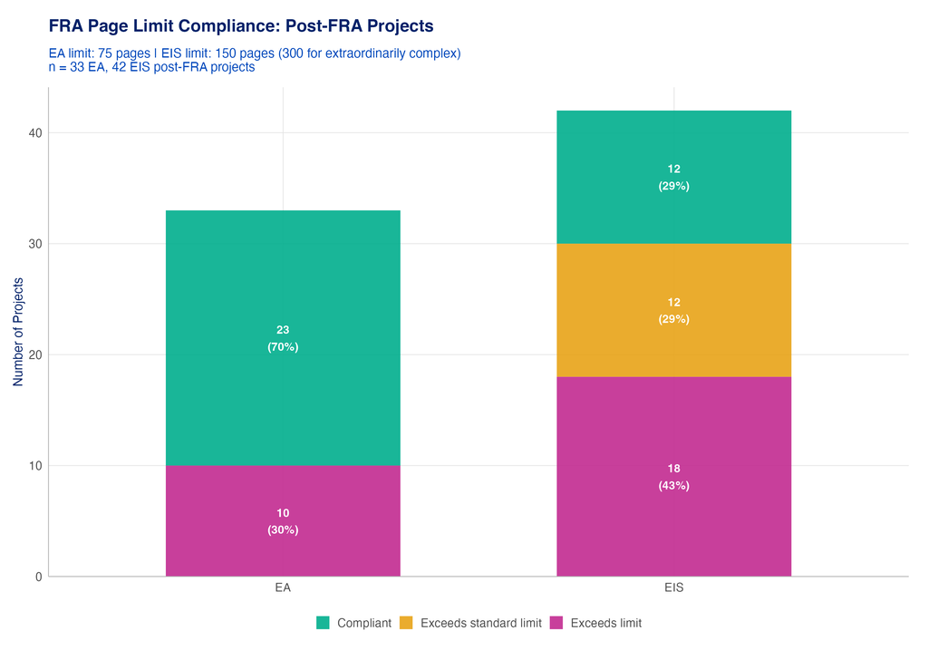

Compliance rates (post-FRA only)

## D5 Key Takeaways

**Causation is uncertain:** The downward trend preceded FRA; the law may have reinforced rather than initiated the decline

# Deliverable 6

## Technology Deep Dives

Three technology areas received dedicated sub-analyses to explore patterns that get lost in aggregate statistics:

**Electricity Transmission** — does line length predict how long the review takes? **Geothermal Energy** — how many sequential NEPA reviews does a single project require? **Pipelines** — how do carbon, hydrogen, and natural gas reviews compare?

## Electricity Transmission Lines

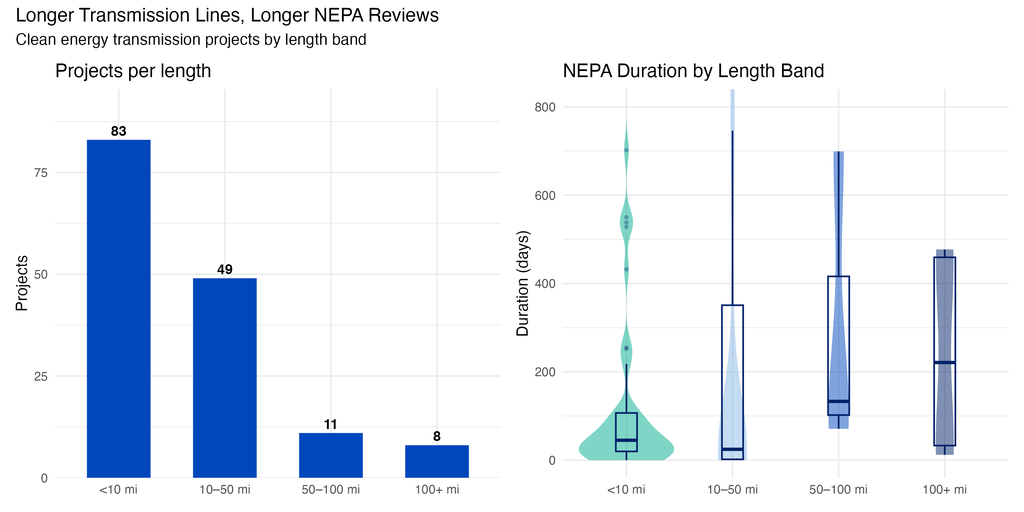

Projects and duration by length band

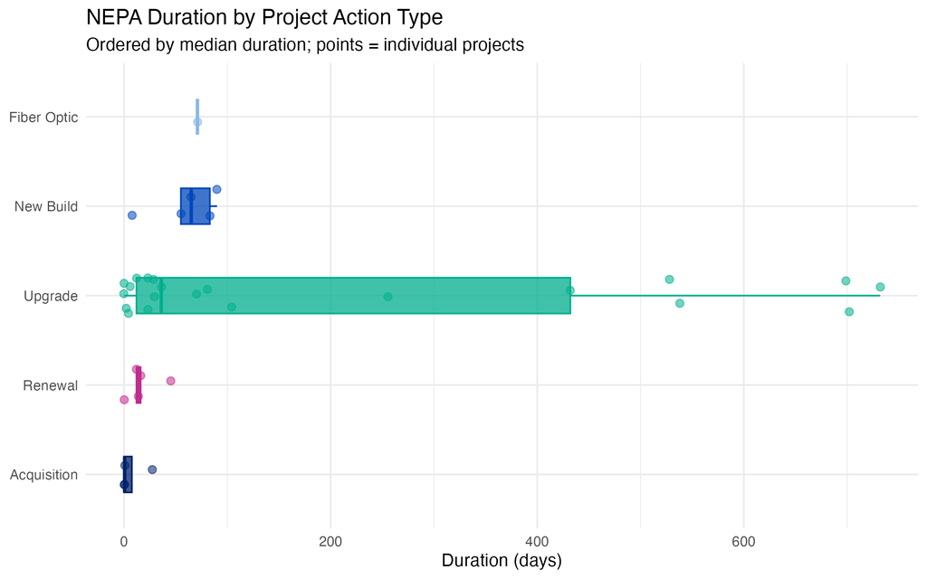

Duration by action type

## Geothermal Energy

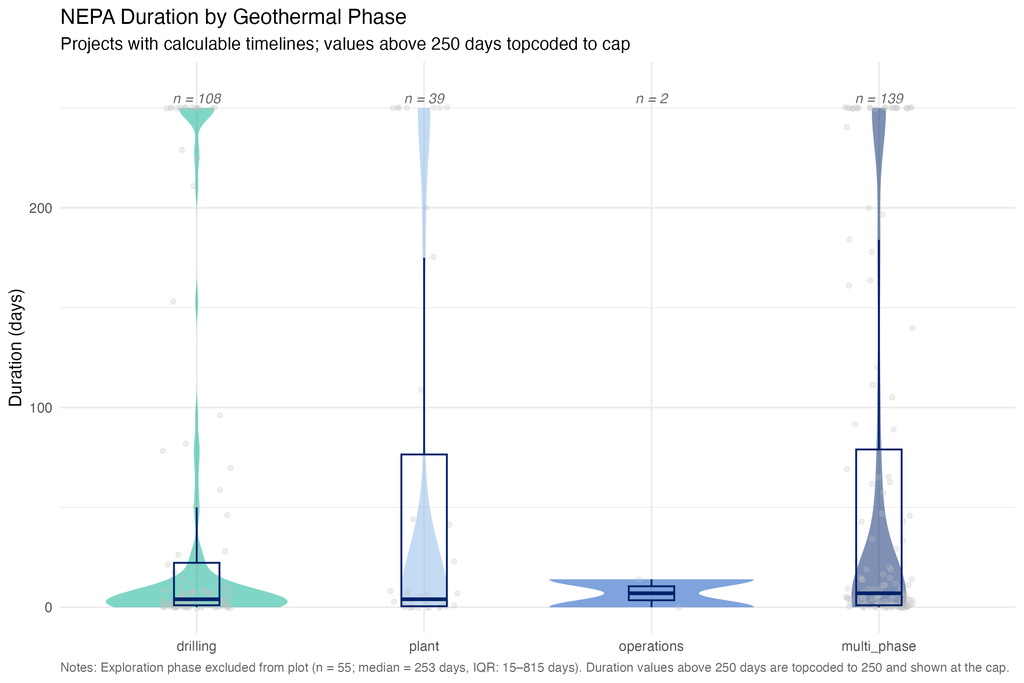

Duration by development phase

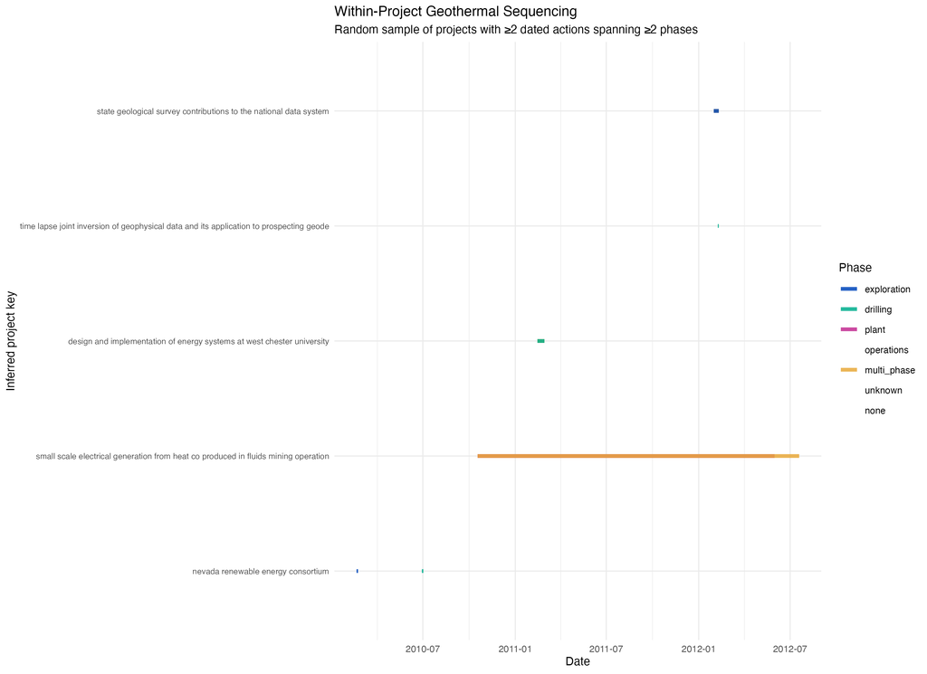

Multi-phase project timelines within a single project

**914 NEPA actions** | **5 phases** | A single geothermal project may require **multiple sequential NEPA reviews** — the total permitting burden is the sum of all phases, not just one review.

## Carbon, Hydrogen & Natural Gas Pipelines

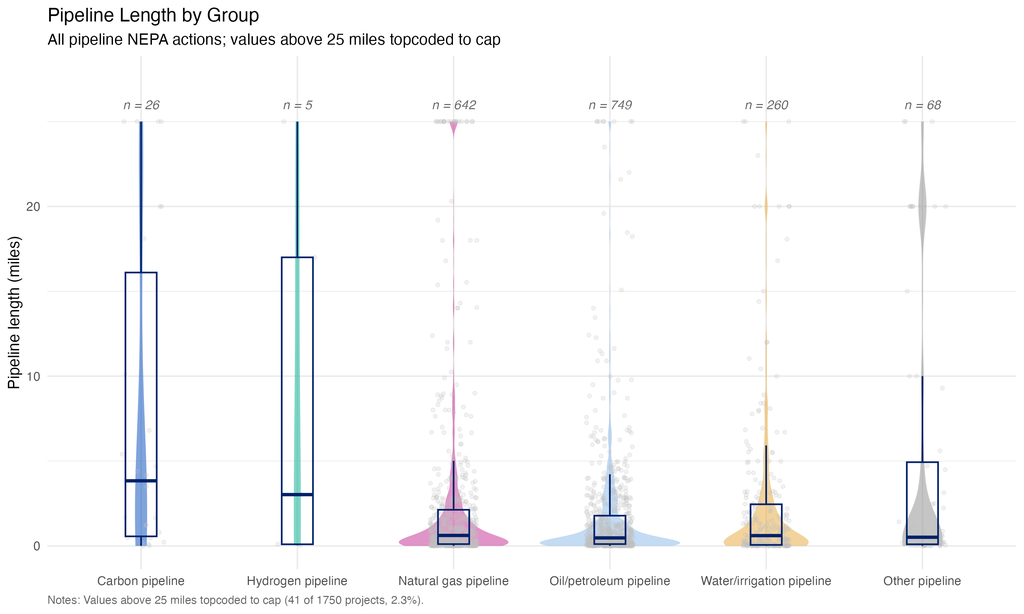

Pipeline length by type

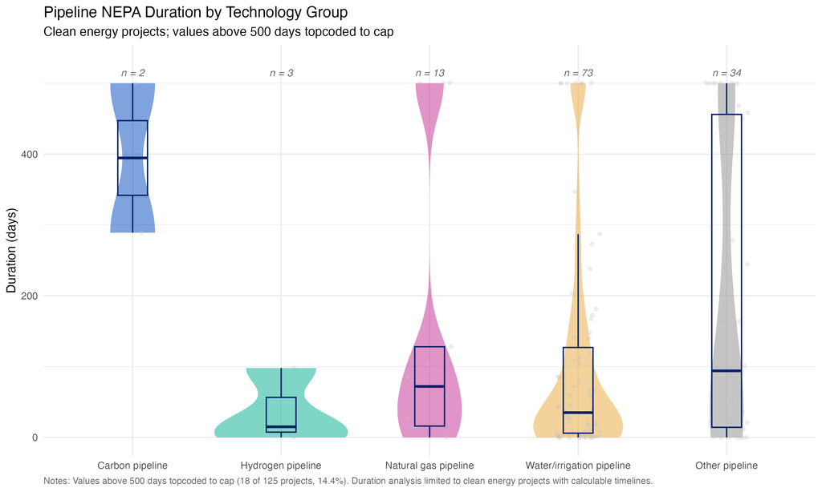

Duration by pipeline type

## D6 Key Takeaways

**Geothermal permitting is cumulative:** Full development requires multiple sequential NEPA reviews; streamlining requires addressing the whole lifecycle

**Mostly upgrades, not new builds:** Most transmission NEPA activity is upgrades and replacements, not greenfield construction

**Carbon/hydrogen data is thin:** Only single-digit to low-double-digit projects have full data — findings are directional, not definitive

## Discussion & Next Steps

**Phase 2 Potential Directions**

1. Why is NEPA triggered? (federal land vs. federal funding)
2. Significance determinations across resource areas
3. Fossil fuel vs. clean energy comparison
4. Timeline outlier case studies (90th percentile EIS)
5. Regulatory categorical exclusion development patterns

**Discussion Questions**

- Which findings most surprise you?
- Which are most actionable for CATF’s policy work?
- Where should Phase 2 focus?

**Ideas for Interactive Tools**

**Shiny App — Project Explorer** Filter by technology, state, agency, and process type → dynamic map + summary statistics

**Plotly Timeline Visualizer** Zoom into cohorts, hover for project names, compare duration distributions interactively

Full Analysis Website | [NEPATEC 2.0](https://huggingface.co/datasets/PNNL/NEPATEC2.0)

Download PDF Version

# Appendix

## A1: NEPA Process Duration — Summary Statistics

[output not shown]

*Statistics derived from projects with complete timelines (both initiation and decision dates). CE statistics are approximate due to lower timeline completeness (30%). See Deliverable 3 for precise figures and confidence intervals.*

## A2: County-Level Maps by Process Type

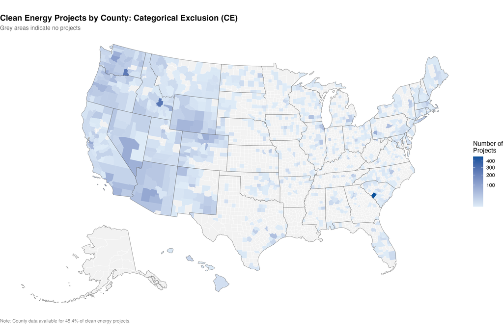

Categorical Exclusions by county

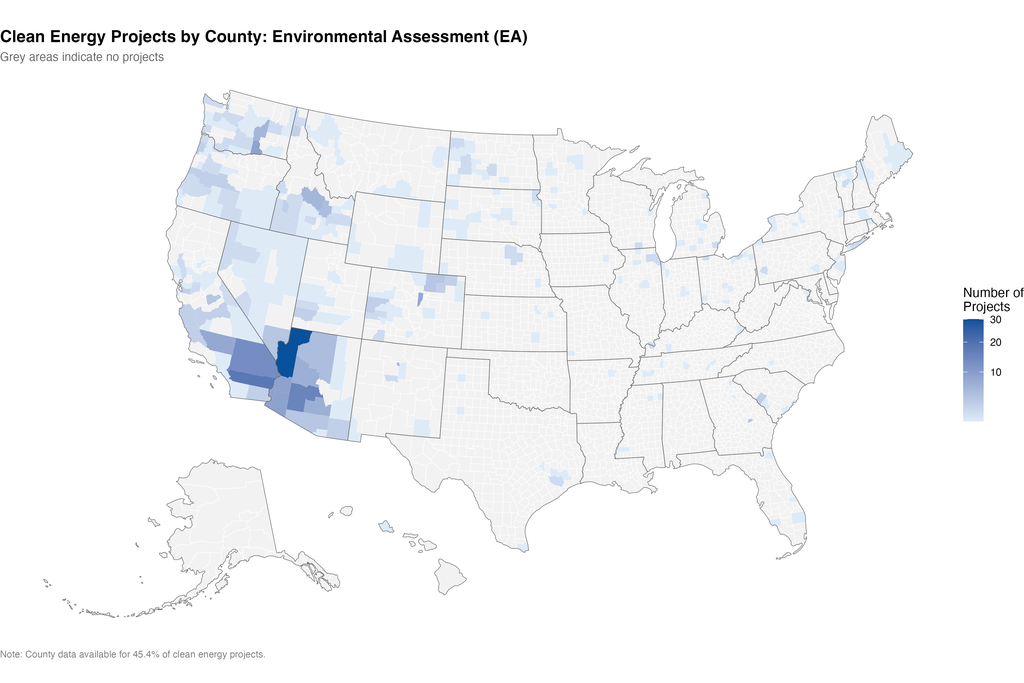

Environmental Assessments by county

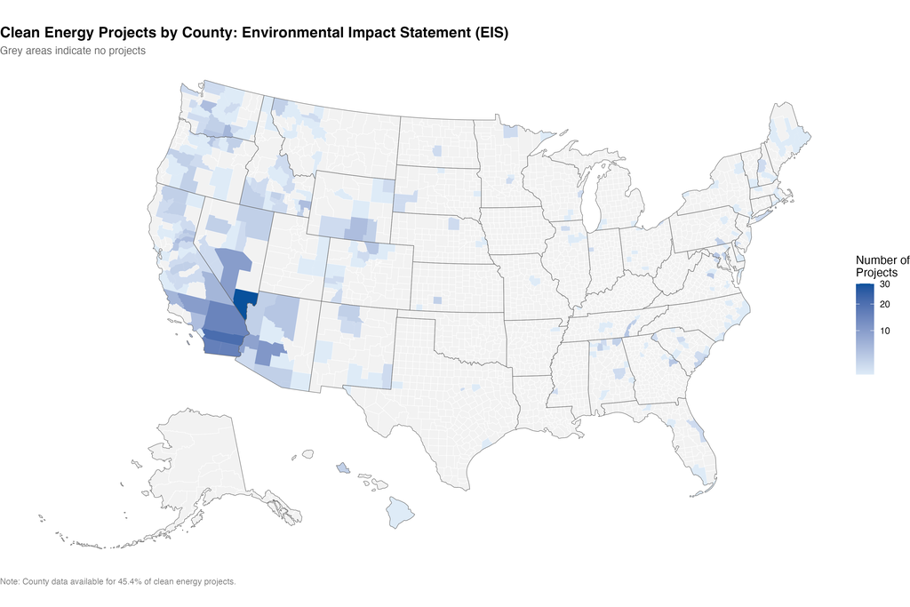

Environmental Impact Statements by county

County coverage: CE 46% | EA 81% | EIS 64%. Western federal land counties show highest activity across all process types.

## A3: Timeline Extraction Methodology

**Two-Stage BERT Pipeline**

1. **Date extraction** — identify all dates in document text with surrounding sentence context (±2 sentences)
2. **Classification** — fine-tuned BERT model assigns each date to:
   - *Initiation* — NOI, application received, scoping notice
   - *Review* — draft publication, comment period
   - *Decision* — ROD, FONSI, approval signature
   - *Other* — expiration dates, referenced past actions

**Selection rules:**

- Decision: prioritize strong signature/approval cues
- Initiation: NOI > application > scoping (in priority order)
- Fallback: use earliest review date when no initiation found

**Coverage Limitations**

**Warning**

- **CE (30%):** Short documents have less temporal information
- **EIS (48%):** RODs often issued as separate documents not linked in dataset
- **EA (62%):** Best coverage; FONSIs typically included in the same document

**Model:** BERT (bert-base-uncased), fine-tuned on manually annotated NEPA document sentences. Class imbalance for initiation dates is a known limitation.

## A4: Transmission — Duration by Region

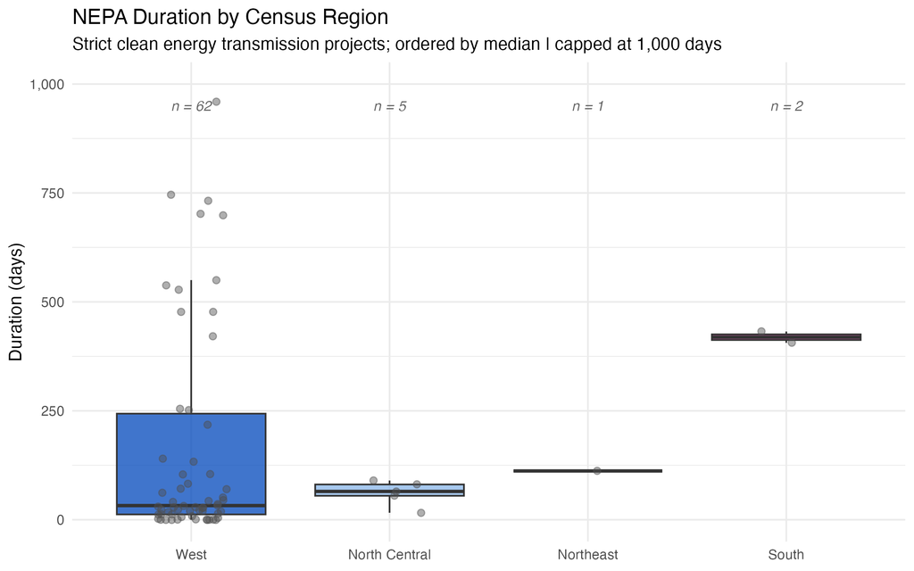

## A5: Geothermal Phase Distribution

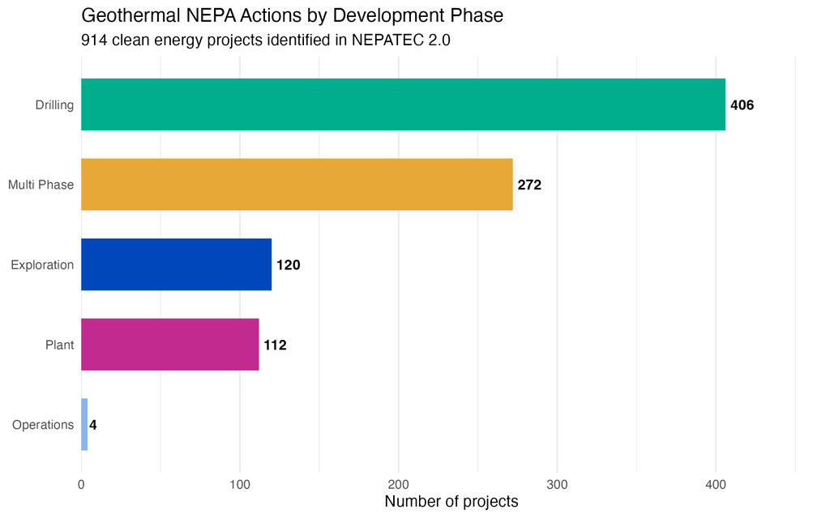

Phase classification uses regex keyword matching on project title and description. Projects matching 2+ phase keyword sets are classified as “multi-phase.” Projects with no keyword match fall back to process type (CE → drilling; EA/EIS → exploration).

## A6: Pipeline Length vs. Duration

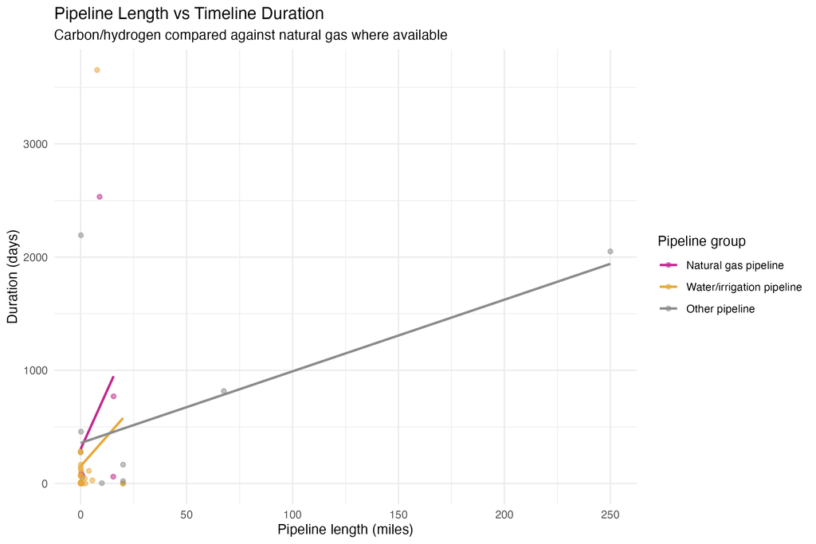

## A7: FRA Regulatory vs. Raw Pages Methodology

**Regulatory Page Calculation**

1. Extract body text from OCR’d PDF
2. Detect appendix boundaries using section-header patterns (e.g., “Appendix A”, “References”, “List of Preparers”)
3. Count words in body text (pre-appendix sections only)
4. Regulatory pages = body word count ÷ 500

**Scale of difference:**

- EAs: regulatory pages ≈ 45–55% of raw page count
- EISs: regulatory pages ≈ 70–80% of raw page count

**Known Edge Cases**

**Warning**

- OCR errors in scanned legacy documents may produce NULL word counts
- Non-standard appendix headers may not be detected
- ~5% of cases: regulatory pages exceed raw pages (OCR text extraction artifact in table-heavy documents)
- Waivers and “extraordinary complexity” exceptions are not distinguished from standard non-compliance

## A8: NEPA Policy Context 2025–2026

| Date | Event |
| --- | --- |
| Jan 20, 2025 | EO 14154 revokes CEQ NEPA regulation authority; instructs agencies to eliminate permitting delays |
| Feb 25, 2025 | CEQ issues interim rule removing NEPA regulations from CFR |
| Apr 23, 2025 | DOI emergency permitting: review timelines reduced to under 1 month |
| May 29, 2025 | Supreme Court (*Seven County v. Eagle County*): agencies may limit NEPA scope to decisional authority |
| Jul 4, 2025 | Reconciliation bill signed — pay-to-play expedited reviews enacted |
| Jul 3, 2025 | DOE, DOI, USDA, Army Corps, DOT, FERC convert NEPA regulations to nonbinding guidance |
| Jul 23, 2025 | AI Action Plan: EO directs new CEs, NEPA exemption when federal funding < 50% |
| Dec 18, 2025 | SPEED Act passes House — limits on judicial review, new NEPA exemptions proposed |
| Dec 22, 2025 | DOI issues stop-work orders for 5 offshore wind projects including Vineyard Wind 1 |
| Jan 8, 2026 | CEQ adopts final rule: all NEPA regulations removed from Federal Register |

*Source: CATF NEPA & Permitting Reform Timeline. The Phase 1 analysis predates most of these actions. Phase 2 data collection will capture their effects on permitting patterns.*

**Clean Air Task Force** NEPA Clean Energy Analysis — Phase 1

Full Analysis Website | [NEPATEC 2.0 Data](https://huggingface.co/datasets/PNNL/NEPATEC2.0)

Download PDF Version

NEPA Clean Energy Analysis — Phase 1 | See full analysis on website →